# Gender and the Welfare State: Dividing Citizens

POSC 459 — Social Welfare Politics and Policy · Week 13, Wednesday 18 November 2026

*Accessible text version of the Week 13 Wednesday slides — same content in linear order, with no slide-scaling container. Each image carries a text description. Reading: Mettler 1998, Dividing Citizens, chapters 1, 5, and 6.*

[figure not shown]

*Mettler 1998, Dividing Citizens, chs. 1, 5, 6*

*Poster: Social Security Board, 1936–37 · public domain*

## Today

1. From Monday to 1935
2. Mettler’s question
3. Two kinds of citizenship
4. Building unemployment insurance (UI) and Aid to Dependent Children (ADC)
5. Running them, 1936–1950
6. Mettler and Michener, side by side
7. Paper 5

## From Monday to 1935

Monday, Michener: where states got to choose, racial gaps followed

Today, Mettler: Congress faced that choice in **1935**

What to run nationally? What to leave to the states?

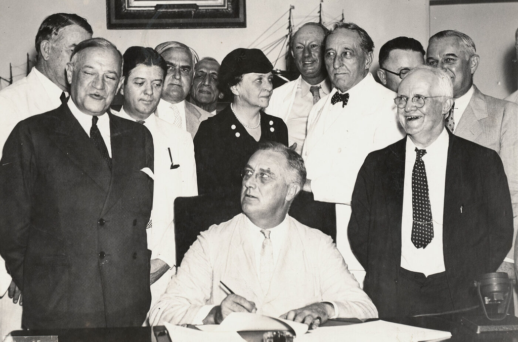

*Roosevelt signs the Social Security Act, Aug. 14, 1935 · FDR Library, CC BY 2.0*

*Michener 2020, pp. 550–51 · Mettler 1998, pp. 1–6*

## Mettler’s question

Before 1935: what citizenship meant was “defined primarily by the individual states”

New Deal: Washington steps in, but only for some

**Structured governance** (her method): look at how a program is designed and who runs it, then at what kind of citizens it makes

*Think: a check from Washington, set by formula, vs. a county caseworker’s decision*

**Social citizenship:** the right to basic economic security, as a member of the community

*Mettler 1998, pp. 1–5, 9 · figure 1, p. 5*

## Divided citizenship

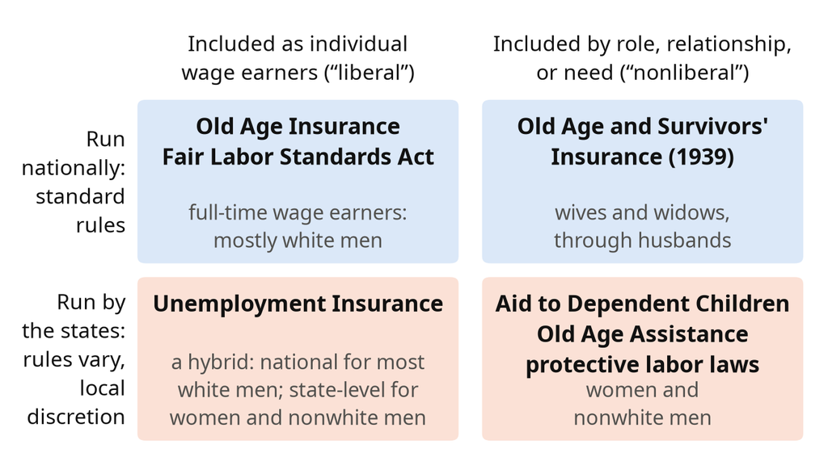

*Redrawn from Mettler, table 1, p. 23 · labels from pp. 5, 23–25*

## Who counted as a worker?

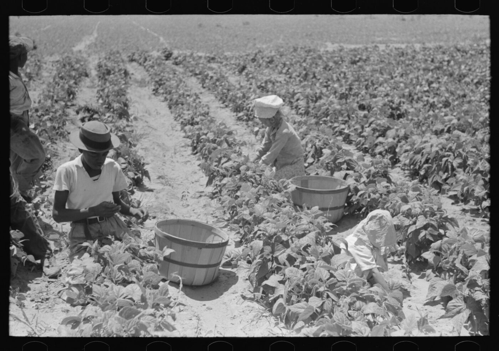

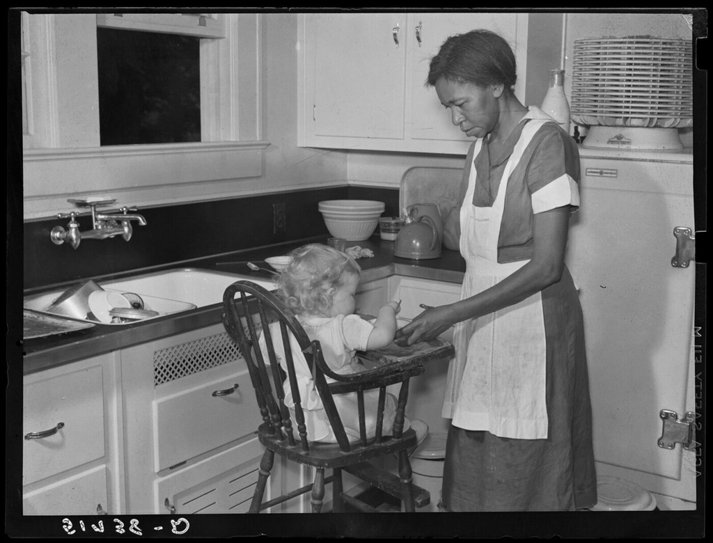

1935: farm workers and domestic workers left out of Social Security and unemployment insurance

Domestic servants on relief, 1934: more than **two-thirds** Black

*Mettler, pp. 20, 26 n. 78, 136 · Photos: Russell Lee, Oklahoma, 1939; Marion Post Wolcott, Atlanta, 1939 · FSA/OWI, Library of Congress*

## Building unemployment insurance

- Perkins’s committee: unemployment insurance (UI) is “the cornerstone”
- **3%** federal payroll tax on employers; a state with its own UI law keeps **90%**
- So states set benefits and who qualifies
- Built to replace “male breadwinners’” wages

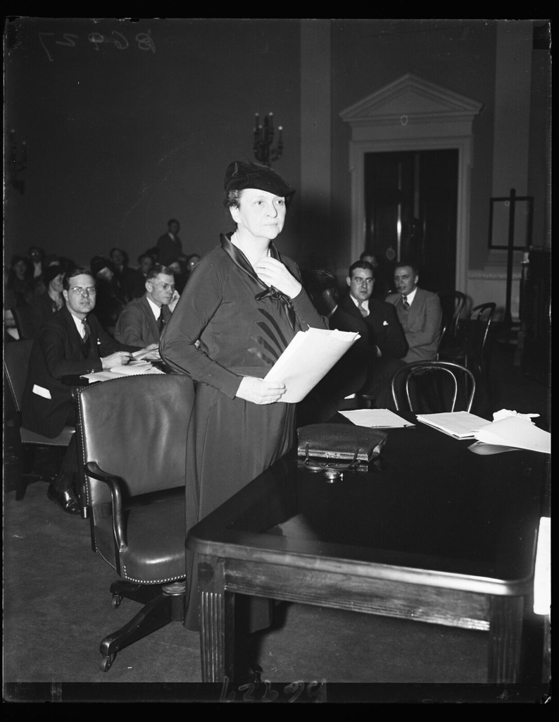

*Perkins, Jan. 22, 1935 · Harris & Ewing, LOC*

*Mettler, ch. 5, pp. 120–28, 136; ch. 6, p. 144*

## Building Aid to Dependent Children (ADC)

- Designed by two Children’s Bureau women: Lenroot and Abbott
- Run by the states; Washington pays **⅓**
- Congress cut the “decency and health” benefit standard
- Benefit ceiling: **$18** a month, first child; **$12** each additional
- For the mother herself: nothing (“no caretakers’ benefits”)

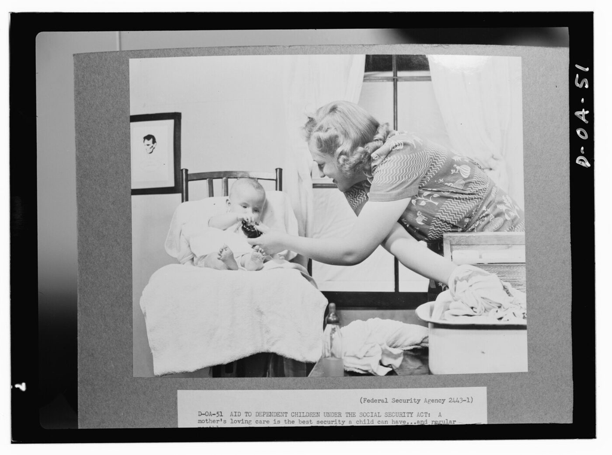

*Federal Security Agency publicity print, 1940s · FSA/OWI, Library of Congress*

*Mettler, ch. 5, pp. 120, 129–40*

## 1935: “fairly comparable ground”

|  | UI | ADC |
| --- | --- | --- |
| Run by | national and state together | national and state together |
| Who qualifies: set by | states | states |
| Merit-based hiring required | no | no |
| Paid for by | payroll tax on employers, held in Washington | grants: **$1 federal for every $2 state** |

Same start in 1935. What split them later: how each was paid for and run.

*Mettler, table 4, p. 142; pp. 141–43*

## UI in practice: who qualifies?

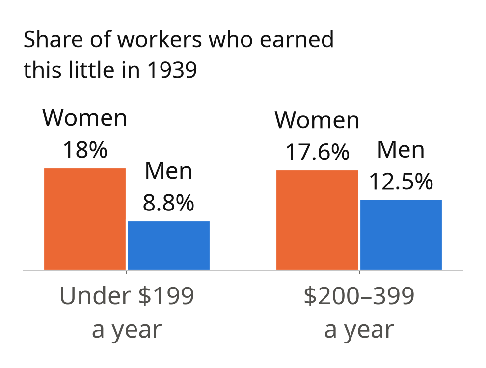

To qualify: earn at least **$100–300** a year (15 states, 1939)

More women than men earned too little

“Available for work” = full-time, daytime

Quit for family reasons (a “domestic quit”): no benefits

*Mettler, ch. 6, pp. 150–53 · 1940 Census, cited*

## Pregnancy and marriage rules

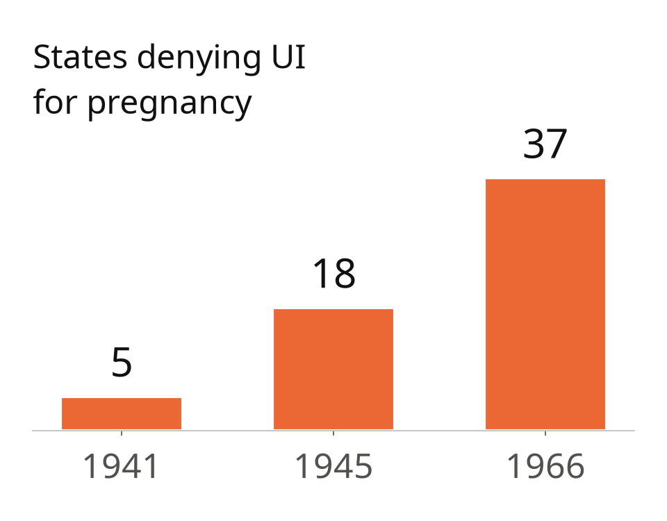

Pregnant: disqualified, or ruled “unavailable” for work

Quit a job to marry: disqualified in **17** states by 1945

“UI acquired a janus-faced character”

*Janus-faced = two-faced: a right for some, a barrier for others*

*Mettler, ch. 6, pp. 154–57, table 5*

## ADC in practice: it depended on where you lived

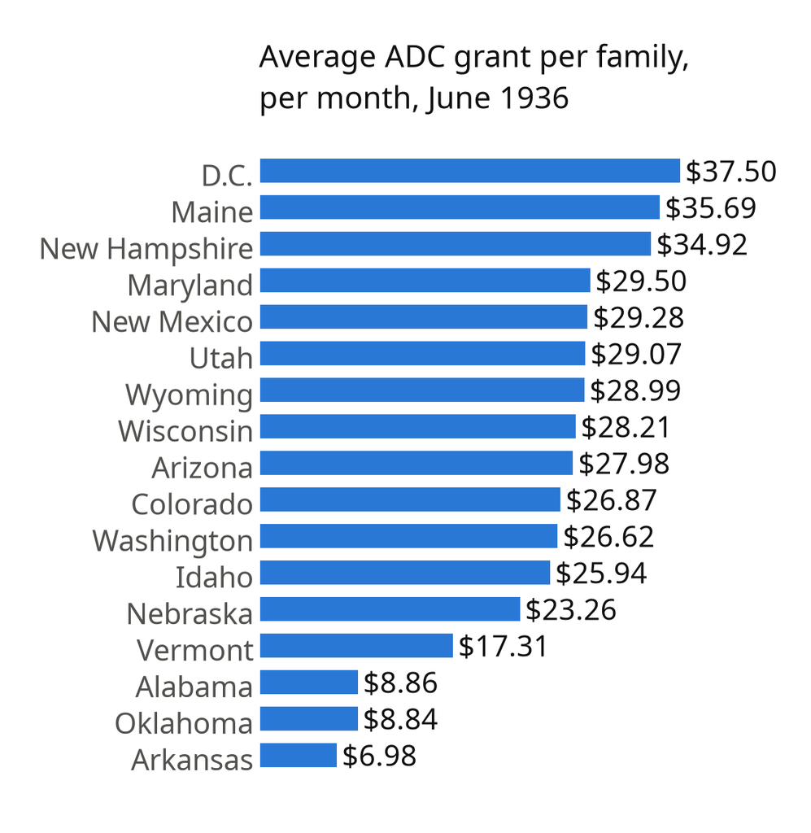

Dec. 1937: **$10.40** a month in Arkansas, **$61.16** in Massachusetts

“Suitable home” rules, caseworkers judging mothers: **31** of 45 states, 1941

Georgia: a racial quota on who got aid

*Mettler, ch. 6, table 6, p. 160; pp. 164–72*

## 1939: who moved up, who stayed

- Widows of covered workers move up to Social Security
- ADC gets a means test (“inscribed with means testing”)
- Black share of ADC families: **14–17%** in the late 1930s → **31%** in 1948

Mettler: 1939 “rescued mostly white, middle-class women”

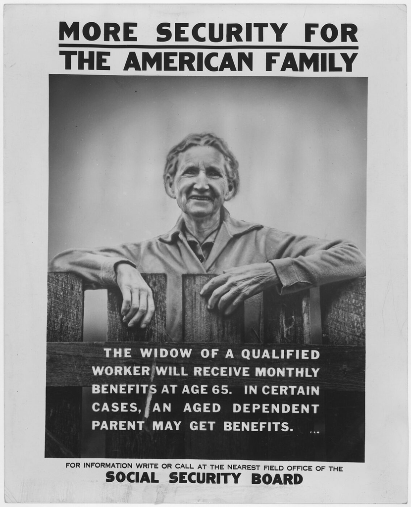

*Social Security Board poster · FDR Library, National Archives*

*Mettler, ch. 6, pp. 167–69*

## Mettler’s conclusion

“it was their designs that propelled them toward their separate fates”

ADC’s design → mothers as “vassals” of each state’s politics

*Mettler, ch. 6, p. 175*

## Mettler and Michener, side by side

|  | Mettler, 1935–1950 | Michener, 2010–2020 |
| --- | --- | --- |
| Who gets sorted | women from men, and by race | by race, and by state |
| What does the sorting | how programs were designed, then run | a court ruling, state choices, waivers, appointees |
| How states got the power | written into the 1935 law: who qualifies, benefits, morals rules | opened by *Sebelius* in 2012; widened by waivers |
| Who is left to the states | women, nonwhite men | Black and Latino adults in the South |
| The author’s explanation | “their designs” | politics undoes policy |

**Paper 5:** the same mechanism twice, or two that only look alike? *Mechanism = the way a policy ends up sorting people*

*Mettler, pp. 5, 23, 175 · Michener, pp. 547, 550–55*

## Paper 5: draft your position

**With a partner, 6 minutes. Write down three things:**

1. **Your position,** in one sentence: are Mettler and Michener describing the same mechanism, or two different ones?
2. **Your evidence:** one page number from Mettler and one from Michener.
3. **Your prediction:** if you’re right, where should we see it next? Name a program.

*Mechanism = the way a policy ends up sorting people · Paper 5 due Fri 11/20, 11:59 p.m.*

## Paper 5, and next week

**Fri 11/20, 11:59 p.m.:** about 600 words

Take a position · cite pages from both readings · say what it predicts

May use Howard ch. 9 and Gilens

**11/23–27:** Thanksgiving, no class

## By 2:15 you should be able to say

How a program is designed and run shapes citizenship

National for white male earners; state-level for women, nonwhite men

Excluded: farm and domestic work

UI and ADC began alike; money and administration split them

ADC: low benefits, different in every state, mothers policed

Mettler and Michener: one mechanism or two?